# Homework #3

Sam Shifflett; shiffy46

```r
data(tips, package="reshape2")
library(ggplot2)
```

```r
head(tips)
```

```
##   total_bill  tip    sex smoker day   time size
## 1      16.99 1.01 Female     No Sun Dinner    2
## 2      10.34 1.66   Male     No Sun Dinner    3
## 3      21.01 3.50   Male     No Sun Dinner    3
## 4      23.68 3.31   Male     No Sun Dinner    2
## 5      24.59 3.61 Female     No Sun Dinner    4
## 6      25.29 4.71   Male     No Sun Dinner    4
```

1.)

```r
numparty <- NROW(tips)
numparty
```

```
## [1] 244
```

2.)

```r
sapply(tips, typeof)
```

```
## total_bill        tip        sex     smoker        day       time
##   "double"   "double"  "integer"  "integer"  "integer"  "integer"
##       size
##  "integer"
```

3.)

```r
day <- factor(tips$day)
week <- c("Thur","Fri","Sat","Sun")
day <- day[order(match(day, week))]
day
```

```
##   [1] Thur Thur Thur Thur Thur Thur Thur Thur Thur Thur Thur Thur Thur Thur
##  [15] Thur Thur Thur Thur Thur Thur Thur Thur Thur Thur Thur Thur Thur Thur
##  [29] Thur Thur Thur Thur Thur Thur Thur Thur Thur Thur Thur Thur Thur Thur
##  [43] Thur Thur Thur Thur Thur Thur Thur Thur Thur Thur Thur Thur Thur Thur
##  [57] Thur Thur Thur Thur Thur Thur Fri  Fri  Fri  Fri  Fri  Fri  Fri  Fri
##  [71] Fri  Fri  Fri  Fri  Fri  Fri  Fri  Fri  Fri  Fri  Fri  Sat  Sat  Sat
##  [85] Sat  Sat  Sat  Sat  Sat  Sat  Sat  Sat  Sat  Sat  Sat  Sat  Sat  Sat
##  [99] Sat  Sat  Sat  Sat  Sat  Sat  Sat  Sat  Sat  Sat  Sat  Sat  Sat  Sat
## [113] Sat  Sat  Sat  Sat  Sat  Sat  Sat  Sat  Sat  Sat  Sat  Sat  Sat  Sat
## [127] Sat  Sat  Sat  Sat  Sat  Sat  Sat  Sat  Sat  Sat  Sat  Sat  Sat  Sat
## [141] Sat  Sat  Sat  Sat  Sat  Sat  Sat  Sat  Sat  Sat  Sat  Sat  Sat  Sat
## [155] Sat  Sat  Sat  Sat  Sat  Sat  Sat  Sat  Sat  Sat  Sat  Sat  Sat  Sat
## [169] Sun  Sun  Sun  Sun  Sun  Sun  Sun  Sun  Sun  Sun  Sun  Sun  Sun  Sun
## [183] Sun  Sun  Sun  Sun  Sun  Sun  Sun  Sun  Sun  Sun  Sun  Sun  Sun  Sun
## [197] Sun  Sun  Sun  Sun  Sun  Sun  Sun  Sun  Sun  Sun  Sun  Sun  Sun  Sun
## [211] Sun  Sun  Sun  Sun  Sun  Sun  Sun  Sun  Sun  Sun  Sun  Sun  Sun  Sun
## [225] Sun  Sun  Sun  Sun  Sun  Sun  Sun  Sun  Sun  Sun  Sun  Sun  Sun  Sun
## [239] Sun  Sun  Sun  Sun  Sun  Sun
## Levels: Fri Sat Sun Thur
```

4.)

```r
female5 <- tips[ which(tips$sex=='Female' & tips$size >= 5), ]
female5
```

```
##     total_bill  tip    sex smoker  day   time size
## 126      29.80 4.20 Female     No Thur  Lunch    6
## 144      27.05 5.00 Female     No Thur  Lunch    6
## 156      29.85 5.14 Female     No  Sun Dinner    5
```

5.)

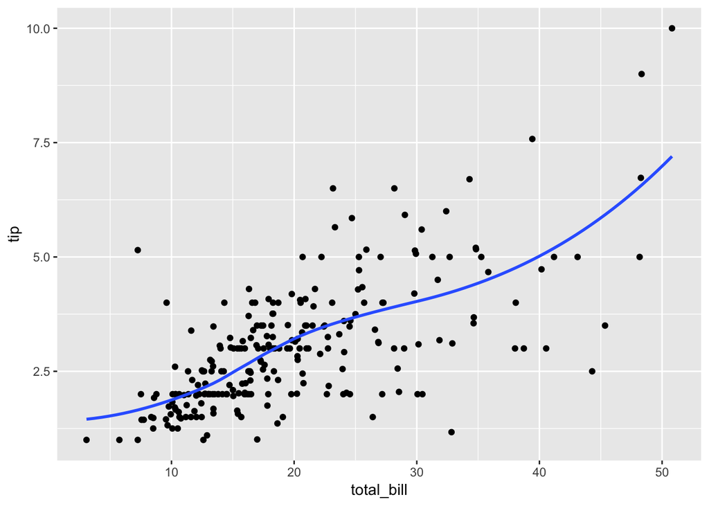

```r
ggplot(tips,aes(y=tip,x=total_bill))+geom_point()+geom_smooth(se=FALSE)
```

The anomolies in this dataset have to do with the large variance in the consistency with the data points. The first type of anomoly is the inflation of data points with over zealous tipping customers. The second is the lower end tippers. With such a large variance it is hard to be predictive with these statisitics. 6.)

```r
tips$tiprate = round(((tips$tip/tips$total_bill)*100),2)
averageTipRate = mean(tips$tiprate)
round(averageTipRate,2)
```

```
## [1] 16.08
```

The average tip rate is 16.08%.

7.)

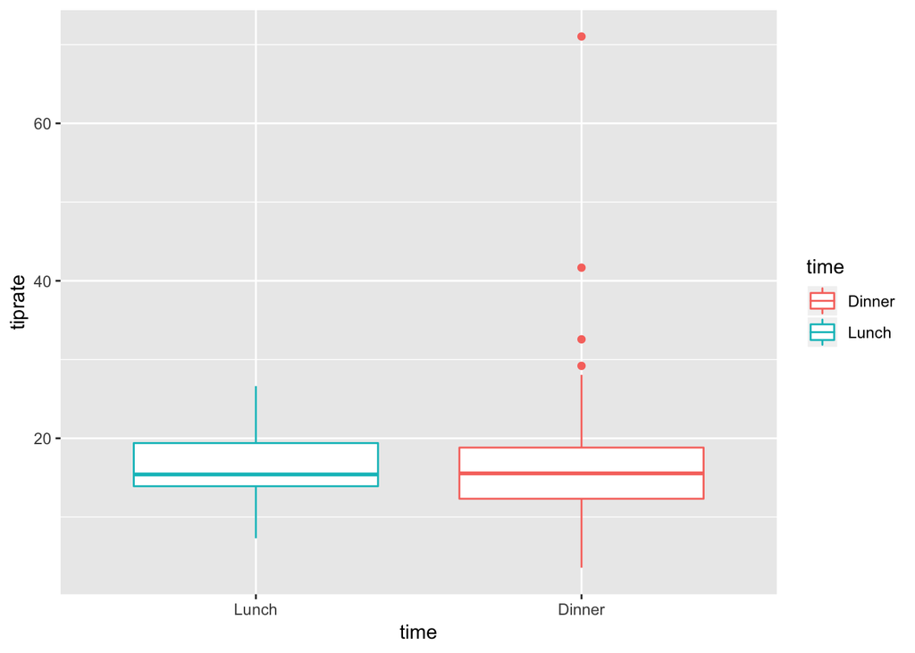

```r
ggplot(tips,aes(x=time,y=tiprate, color=time))+geom_boxplot()+scale_x_discrete(limits=c("Lunch","Dinner"))
```

8.)

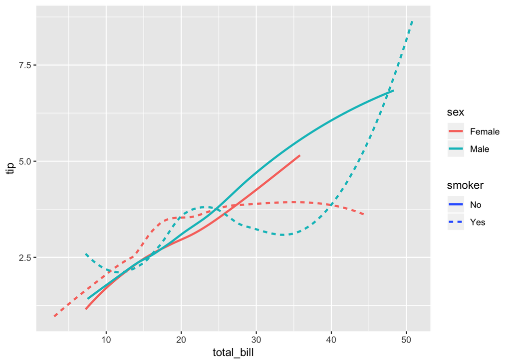

```r
ggplot(tips, aes(x=total_bill,y=tip))+geom_smooth(se=FALSE, aes(color=sex,linetype = smoker))
```

This is an interesting observation, it seems that the smokers are more generous for lower costing food(more tips). But, as soon as the bill goes over 25$ there is a dramatic shift in tip amount for the smokers. There is also more of a consistent linear ascent for the non-smokers as compared to the volatility of the smokers.

9.)

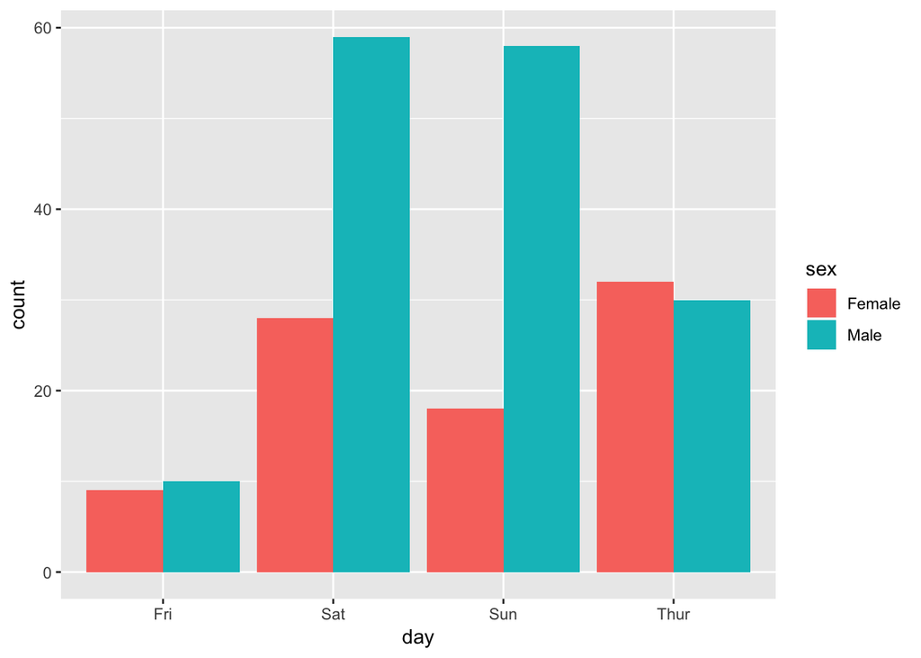

```r
ggplot(data=tips, aes(x=day)) + geom_bar(aes(fill=sex),position='dodge')
```